# quarto-input54ed1fba

The rest of the produced graphs are a part of the analysis.

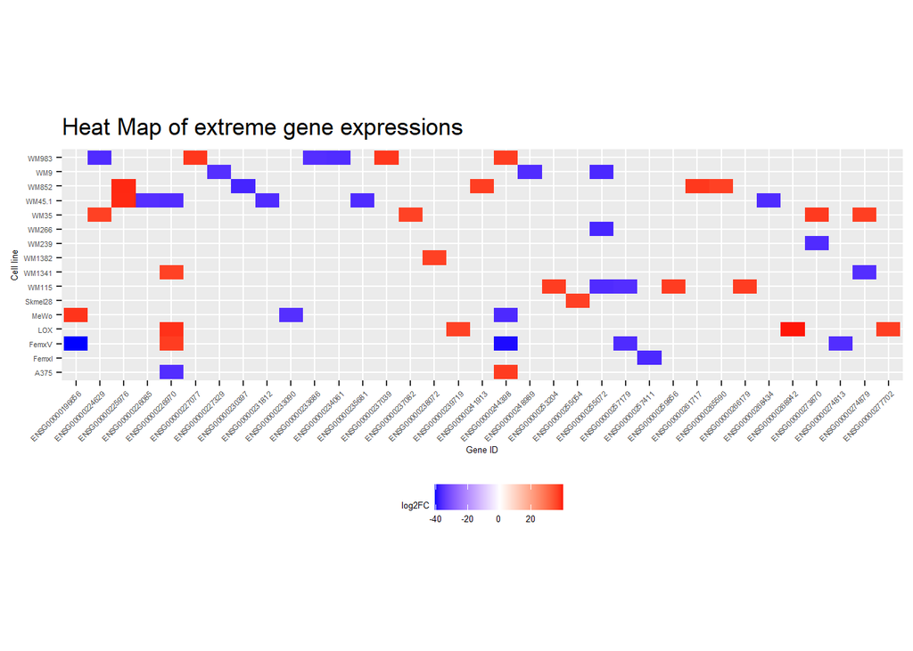

```r
human_aug_log2fc_long <- human_aug_log2fc_wide |>
  pivot_longer(cols = starts_with("ENSG"),
               names_to = "gene",
               values_to = "log2_fold_change")

down <- human_aug_log2fc_long |>
  arrange(log2_fold_change)|>
  head(25)

up <- human_aug_log2fc_long |>
  arrange(desc(log2_fold_change))|>
  head(25)

up_and_down <- bind_rows(down, up)

#up_and_down we dont want to render it

up_and_down|>
ggplot(aes(x = gene,
           y = cell_line,
           fill = log2_fold_change))+
  geom_tile()+
  scale_fill_gradient2(low = 'blue',
                       high ='red',
                       midpoint= 0)+
  theme(axis.text.x = element_text(angle = 45,
                                   vjust = 1,
                                   hjust=1),
        axis.text=element_text(size=4),
        axis.title=element_text(size=5))+
  theme(legend.position = 'bottom',
        legend.key.size = unit(5, 'mm'),
        legend.title=element_text(size=5),
        legend.text=element_text(size=5))+
  labs(title = "Heat Map of extreme gene expressions",
       x = "Gene ID",
       y = "Cell line",
       fill = "log2FC")+
  coord_fixed(ratio=0.6)
```

```r
ggsave("../results/04_key_plot_3.png", bg = "white", device="png")
```

This analysis will see which genes are significantly up and down regulated in the treatment trials

Here we begin by loading the augmented mouse dataset

Now lets do an analysis to see which genes are significantly up and down regulated in each of the treatment trials.

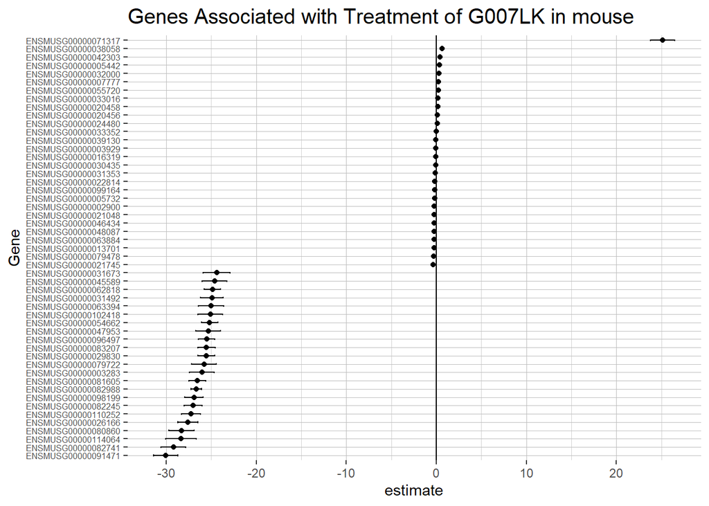

```r
mouse_G007LK_lm <- generate_lm_genes(mouse_df, 'G007LK')
signif_genes_error_bars(mouse_G007LK_lm, 'G007LK')
```

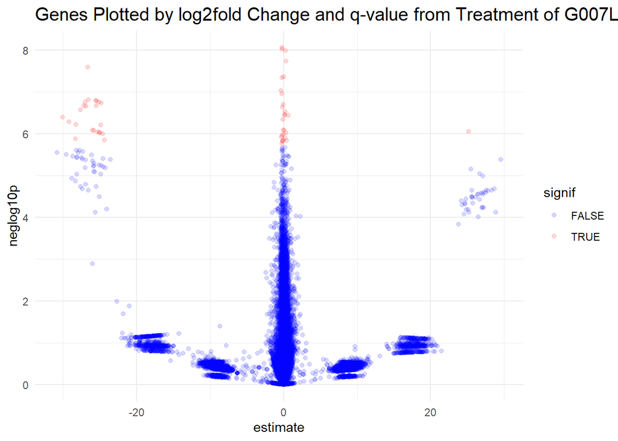

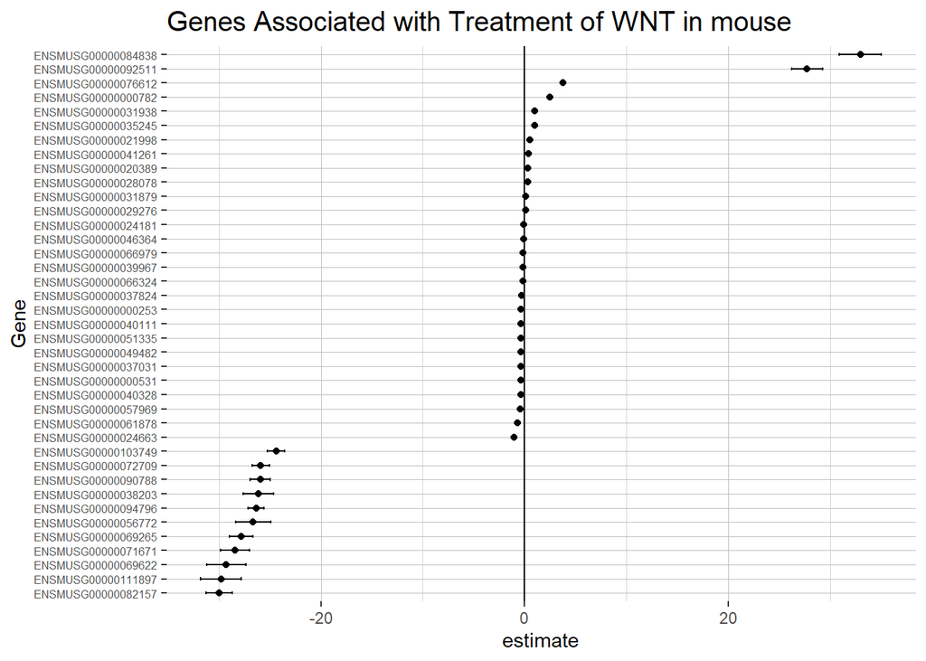

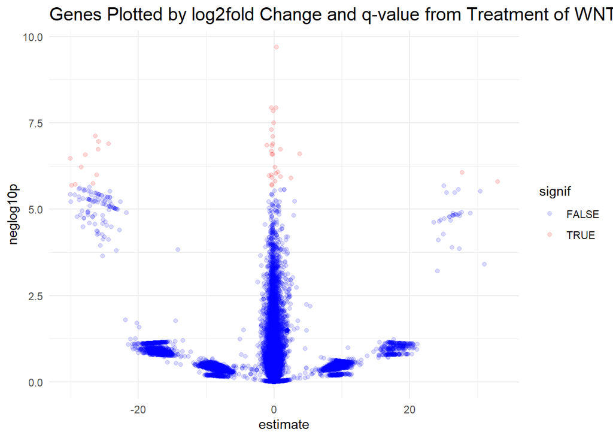

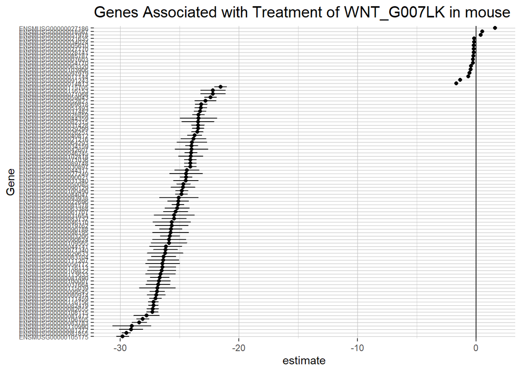

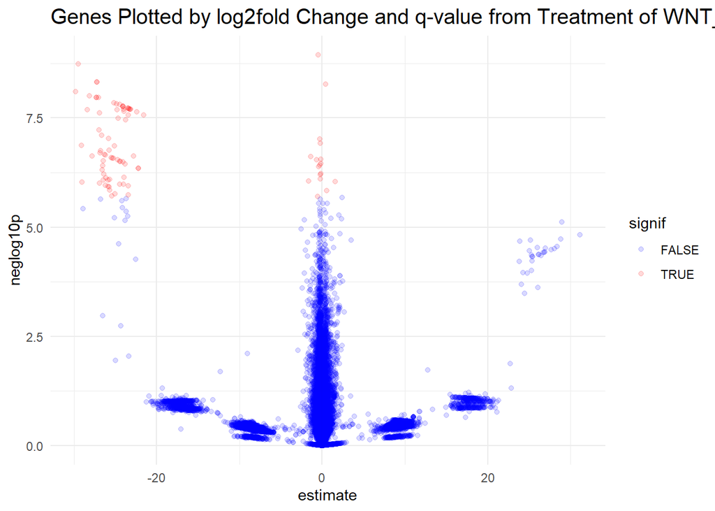

Lets also make a Venn diagram of which significantly regulated genes are present in multiple treatments

```
[1] 1
```

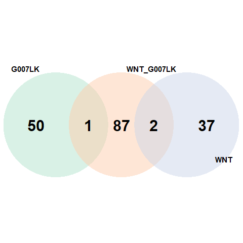

```
[1] TRUE
```